# Crosswords: Accessibility and Representation

#### Gender

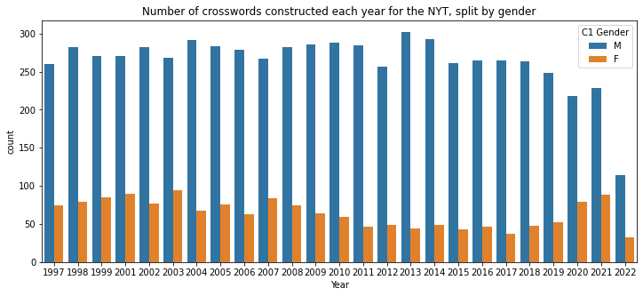

```python
plt.figure(figsize=(12,5))
sns.countplot(data=nytData,x="Year",hue="C1 Gender")
plt.title("Number of crosswords constructed each year for the NYT, split by gender")
```

We can see that, the crossword scene in the New York Times is primarily male dominated.

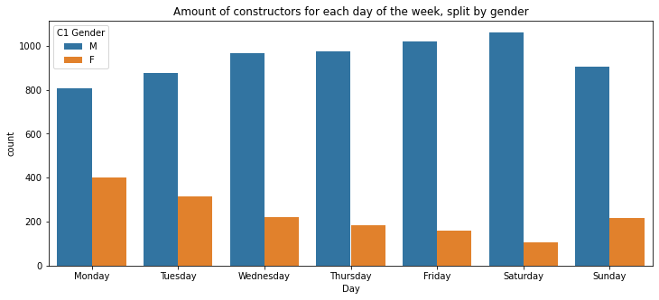

```python
daysOfWeek=["Monday","Tuesday","Wednesday","Thursday","Friday","Saturday","Sunday"]
plt.figure(figsize=(12,5))
sns.countplot(data=nytData,x="Day",hue="C1 Gender")
plt.title("Amount of constructors for each day of the week, split by gender")
```

As the week goes on, more and more male constructors appear, and unfortunately, the number of female constructors decrease. Except for Sunday, which has a similar difficulty to Wed/Thurs puzzles. One may infer that the tougher difficulty may cause more female constructors to not construct.

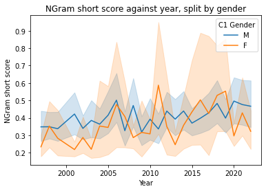

```python
sns.lineplot(data=nytData,x="Year",y="NShort",hue="C1 Gender")
plt.title("NGram short score against year, split by gender")
plt.ylabel("NGram short score")
```

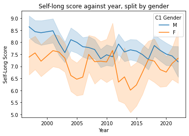

```python
sns.lineplot(data=nytData,x="Year",y="NLong",hue="C1 Gender")
plt.ylabel("Self-Long Score")
plt.title("Self-long score against year, split by gender")
```

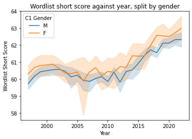

```python
sns.lineplot(data=nytData,x="Year",y="AShort",hue="C1 Gender")
plt.ylabel("Wordlist Short Score")
plt.title("Wordlist short score against year, split by gender")
```

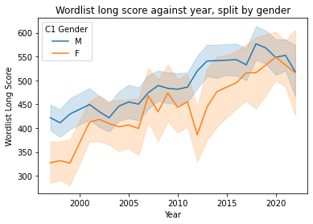

```python
sns.lineplot(data=nytData,x="Year",y="ALong",hue="C1 Gender")
plt.ylabel("Wordlist Long Score")
plt.title("Wordlist long score against year, split by gender")
```

We can see that crosswordese generally remains similar, but freshness is higher among men

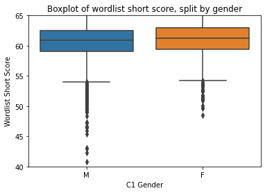

```python
sns.boxplot(data=nytData,x="C1 Gender",y="AShort")
plt.ylim((40,65))
plt.ylabel("Wordlist Short Score")
plt.title("Boxplot of wordlist short score, split by gender")
```

Generally, using wordlists, there seems to be no trend between the crosswordese amount between men and women.

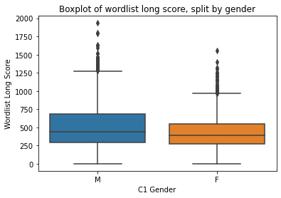

```python
sns.boxplot(data=nytData,x="C1 Gender",y="ALong")
plt.ylabel("Wordlist Long Score")
plt.title("Boxplot of wordlist long score, split by gender")
```

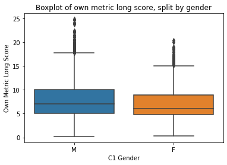

```python
sns.boxplot(data=nytData,x="C1 Gender",y="NLong")
plt.ylabel("Own Metric Long Score")
plt.title("Boxplot of own metric long score, split by gender")
```

Using wordlists and NGrams, men have a higher long answer score then women.

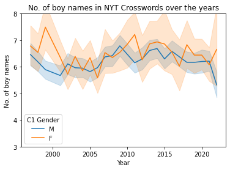

```python
sns.lineplot(data=nytData,y="BNames",x="Year",hue="C1 Gender")
plt.ylabel("No. of boy names")
plt.title("No. of boy names in NYT Crosswords over the years")
plt.ylim((3,8))
pass
```

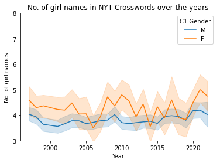

```python
sns.lineplot(data=nytData,y="GNames",x="Year",hue="C1 Gender")
plt.ylabel("No. of girl names")
plt.title("No. of girl names in NYT Crosswords over the years")
plt.ylim((3,8))
pass
```

Between men and women, they use similar number of boy's names used. However, women are generally more inclined to use girl names.